# CommunityContribution-Fall24

Author

Marissa Inga (mi2548) and Victoria Lin (vl2534)

## Machine Learning in R

We wanted to take a closer look at how Machine Learning algorithms may be leveraged in R. We found that a range of resources are available, and decided to do a deep dive into the Random Forest library using the UCI Heart Disease Dataset from Kaggle.

### Initial Setup

```r
library(dplyr)
library(tidyverse)
library(ggplot2)
```

### Data Preparation

#### Data Loading

We chose to use the UCI Heart Disease Dataset from Kaggle as our dataset for this tutorial. This dataset is multivariate and provides 14 independent variables and 1 dependent variable, which is the predicted health attribute.

```r
data <- read_csv('heart_disease_uci.csv', col_names = TRUE)
head(data)
```

```
# A tibble: 6 × 16
     id   age sex    dataset   cp      trestbps  chol fbs   restecg thalch exang
  <dbl> <dbl> <chr>  <chr>     <chr>      <dbl> <dbl> <lgl> <chr>    <dbl> <lgl>
1     1    63 Male   Cleveland typica…      145   233 TRUE  lv hyp…    150 FALSE
2     2    67 Male   Cleveland asympt…      160   286 FALSE lv hyp…    108 TRUE
3     3    67 Male   Cleveland asympt…      120   229 FALSE lv hyp…    129 TRUE
4     4    37 Male   Cleveland non-an…      130   250 FALSE normal     187 FALSE
5     5    41 Female Cleveland atypic…      130   204 FALSE lv hyp…    172 FALSE
6     6    56 Male   Cleveland atypic…      120   236 FALSE normal     178 FALSE
# ℹ 5 more variables: oldpeak <dbl>, slope <chr>, ca <dbl>, thal <chr>,
#   num <dbl>
```

The columns are described below:

1. `id` (Unique id for each patient)
2. `age` (Age of the patient in years)
3. `origin` (place of study)
4. `sex` (Male/Female)
5. `cp` chest pain type ([typical angina, atypical angina, non-anginal, asymptomatic])
6. `trestbps` resting blood pressure (resting blood pressure (in mm Hg on admission to the hospital))
7. `chol` (serum cholesterol in mg/dl)
8. `fbs` (if fasting blood sugar > 120 mg/dl)
9. `restecg` (resting electrocardiographic results)  
   – Values: [normal, stt abnormality, lv hypertrophy]
10. `thalach`: maximum heart rate achieved
11. `exang`: exercise-induced angina (True/ False)
12. `oldpeak`: ST depression induced by exercise relative to rest
13. `slope`: the slope of the peak exercise ST segment
14. `ca`: number of major vessels (0-3) colored by fluoroscopy
15. `thal`: [normal; fixed defect; reversible defect]
16. `num`: the predicted attribute

#### Data Cleaning

Now that we have loaded our data, we can take a look at the contents and do some cleaning. First we drop the id column:

```r
data_cleaned <- data
data_cleaned <- select(data_cleaned, names(data_cleaned)[2:16])
```

```r
colSums(is.na(data_cleaned))
```

```
     age      sex  dataset       cp trestbps     chol      fbs  restecg
       0        0        0        0       59       30       90        2
  thalch    exang  oldpeak    slope       ca     thal      num
      55       55       62      309      611      486        0
```

```r
data_cleaned$trestbps[is.na(data_cleaned$trestbps)] <- median(data_cleaned$trestbps, na.rm = TRUE)
data_cleaned$chol[is.na(data_cleaned$chol)] <- median(data_cleaned$chol, na.rm = TRUE)
data_cleaned$fbs[is.na(data_cleaned$fbs)] <- median(data_cleaned$fbs, na.rm = TRUE)
data_cleaned$restecg[is.na(data_cleaned$restecg)] <- mode(data_cleaned$restecg)
data_cleaned$thalch[is.na(data_cleaned$thalch)] <- median(data_cleaned$thalch, na.rm = TRUE)
data_cleaned$exang[is.na(data_cleaned$exang)] <- median(data_cleaned$exang, na.rm = TRUE)
data_cleaned$oldpeak[is.na(data_cleaned$oldpeak)] <- median(data_cleaned$oldpeak, na.rm = TRUE)
data_cleaned$slope[is.na(data_cleaned$slope)] <- mode(data_cleaned$slope)
data_cleaned$ca[is.na(data_cleaned$ca)] <- median(data_cleaned$ca, na.rm = TRUE)
data_cleaned$thal[is.na(data_cleaned$thal)] <- mode(data_cleaned$thal)

colSums(is.na(data_cleaned))
```

```
     age      sex  dataset       cp trestbps     chol      fbs  restecg
       0        0        0        0        0        0        0        0
  thalch    exang  oldpeak    slope       ca     thal      num
       0        0        0        0        0        0        0
```

Now we take a look at the `character` type columns, and convert to factor:

```r
data_cleaned$sex <- as.factor(data_cleaned$sex)
data_cleaned$dataset <- as.factor(data_cleaned$dataset)
data_cleaned$cp <- as.factor(data_cleaned$cp)
data_cleaned$restecg <- as.factor(data_cleaned$restecg)
data_cleaned$slope <- as.factor(data_cleaned$slope)
data_cleaned$thal <- as.factor(data_cleaned$thal)
data_cleaned$num <- as.factor(data_cleaned$num)


summary(Filter(is.factor, data_cleaned))
```

```
     sex               dataset                  cp                  restecg
 Female:194   Cleveland    :304   asymptomatic   :496   character       :  2
 Male  :726   Hungary      :293   atypical angina:174   lv hypertrophy  :188
              Switzerland  :123   non-anginal    :204   normal          :551
              VA Long Beach:200   typical angina : 46   st-t abnormality:179

         slope                    thal     num
 character  :309   character        :486   0:411
 downsloping: 63   fixed defect     : 46   1:265
 flat       :345   normal           :196   2:109
 upsloping  :203   reversable defect:192   3:107
                                           4: 28
```

```r
summary(Filter(is.numeric, data_cleaned))
```

```
      age           trestbps        chol            fbs           thalch
 Min.   :28.00   Min.   :  0   Min.   :  0.0   Min.   :0.00   Min.   : 60.0
 1st Qu.:47.00   1st Qu.:120   1st Qu.:177.8   1st Qu.:0.00   1st Qu.:120.0
 Median :54.00   Median :130   Median :223.0   Median :0.00   Median :140.0
 Mean   :53.51   Mean   :132   Mean   :199.9   Mean   :0.15   Mean   :137.7
 3rd Qu.:60.00   3rd Qu.:140   3rd Qu.:267.0   3rd Qu.:0.00   3rd Qu.:156.0
 Max.   :77.00   Max.   :200   Max.   :603.0   Max.   :1.00   Max.   :202.0
    oldpeak              ca
 Min.   :-2.6000   Min.   :0.0000
 1st Qu.: 0.0000   1st Qu.:0.0000
 Median : 0.5000   Median :0.0000
 Mean   : 0.8533   Mean   :0.2272
 3rd Qu.: 1.5000   3rd Qu.:0.0000
 Max.   : 6.2000   Max.   :3.0000
```

Now that our data is cleaned, we want to split our data into a train set and test set. R makes this easy with the sample function. We are choosing to hold out 25% of our data for testing.

```r
sample <- sample.int(n = nrow(data_cleaned), size = floor(.75*nrow(data_cleaned)), replace = F)
train <- data_cleaned[sample, ]
test  <- data_cleaned[-sample, ]
```

### Random Forest Package Exploration

#### Fitting the data

After loading in `randomForest`, we separate our data into X and Y vectors, then feed them to the randomForest package to get a fitted model.

```r
library(randomForest)
trainX <- train[, !(names(train) %in% c('num'))]
trainY <- train$num

testX <- test[, !(names(test) %in% c('num'))]
testY <- test$num


# num is what we are trying to predict
# 0 is no heart disease, 1-4 is severity
train <- cbind(trainX, num = trainY)
fit <- randomForest(num ~ ., data = train,
                    ntree = 100, # Number of trees
                    mtry = 10, # Number of variables sampled as candidates per tree
                    maxnodes = 7, # Max # of terminal nodes (limit tree growth)
                    nodesize = 0.01 * nrow(train)) # Stopping criterion limiting depth of trees
```

#### Generating predictions

Generating predictions with `randomForest` is straightforward - just call `predict` on the fitted model, and feed in the X vector to predict for.

```r
pred <- predict(fit, testX)
test <- cbind(testX, pred = pred)
```

#### Analyzing performance

The `randomForest` package has some helpful functions to analyze performance right out of the box. The `varImpPlot` function automatically generates a visualization of variable importance by MeanDecreaseGini.

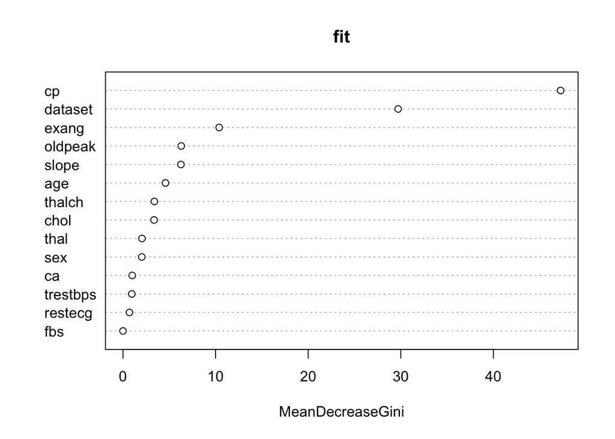

```r
varImpPlot(fit)
```

The `importance` function returns a table version of variable importance by MeanDecreaseGini.

```r
importance(fit)
```

```
         MeanDecreaseGini
age             4.5934941
sex             2.0348336
dataset        29.7134277
cp             47.2537144
trestbps        0.9548551
chol            3.3548672
fbs             0.0000000
restecg         0.7016639
thalch          3.3883495
exang          10.3906070
oldpeak         6.2891274
slope           6.2558574
ca              1.0011488
thal            2.0564746
```

With the help of the `caret` library, we can get additional helpful information like the confusion matrix, which breaks down our performance by class.

```r
library(caret)
confusionMatrix(table(pred,testY))
```

```
Confusion Matrix and Statistics

    testY
pred  0  1  2  3  4
   0 91 18  3  3  0
   1 21 52 18 16  8
   2  0  0  0  0  0
   3  0  0  0  0  0
   4  0  0  0  0  0

Overall Statistics

               Accuracy : 0.6217
                 95% CI : (0.5556, 0.6847)
    No Information Rate : 0.487
    P-Value [Acc > NIR] : 2.703e-05

                  Kappa : 0.3741

 Mcnemar's Test P-Value : NA

Statistics by Class:

                     Class: 0 Class: 1 Class: 2 Class: 3 Class: 4
Sensitivity            0.8125   0.7429   0.0000  0.00000  0.00000
Specificity            0.7966   0.6062   1.0000  1.00000  1.00000
Pos Pred Value         0.7913   0.4522      NaN      NaN      NaN
Neg Pred Value         0.8174   0.8435   0.9087  0.91739  0.96522
Prevalence             0.4870   0.3043   0.0913  0.08261  0.03478
Detection Rate         0.3957   0.2261   0.0000  0.00000  0.00000
Detection Prevalence   0.5000   0.5000   0.0000  0.00000  0.00000
Balanced Accuracy      0.8046   0.6746   0.5000  0.50000  0.50000
```